# Short Report 2

Jake VanCampen

11-Feb-2018

This report continues to analyze base error coverage data from two ancient individuals, The Neanderthal, and the Denisovan. The question we are interested in answering is does the total coverage vary with nearby GC content, and by how much? Also, how well does our model of this phenomenon fit the data.

First I’ll read in the data as before, checking out the head of each dataset.

```r
denis <- read_delim('Data/denisova.counts', delim = ' ')
neand <- read_delim('Data/altai.counts', delim = ' ')

head(denis)
```

```
## # A tibble: 6 x 5
##   region     A     T     C     G
##    <chr> <int> <int> <int> <int>
## 1     mt     0     0     0   174
## 2     mt   177     0     0     0
## 3     mt     0   179     0     0
## 4     mt     1     0   183     0
## 5     mt   190     0     0     1
## 6     mt     0     0   195     0
```

```r
head(neand)
```

```
## # A tibble: 6 x 5
##   region     A     T     C     G
##    <chr> <int> <int> <int> <int>
## 1     mt    11     1     1    48
## 2     mt   177     0     0     1
## 3     mt     0   221     0     0
## 4     mt     0     0   251     0
## 5     mt   355     1     0     0
## 6     mt     0     4   390     0
```

To determine how coverage varies with nearby GC content, first the truebase for each site will be determined, and the GC content for a window of ±K bases can be calculated from the true bases.

```r
# determine the truebase
denis$truebase <- apply(denis[2:5], 1, which.max)
neand$truebase <- apply(neand[2:5], 1, which.max)

# determine the total coverage for each individual
denis$coverage <- apply(denis[2:5],1,sum)
neand$coverage <- apply(neand[2:5],1,sum)

# make truebase == 1 if true base is G or C, else make 0
denis$gc <- ifelse(denis$truebase >= 3,1,0)
neand$gc <- ifelse(neand$truebase >= 3,1,0)
```

Now we can determine the gc content by taking the rolling mean of the column ‘gc’, this will be the gc content for the centered sliding window of size k. I will calculate cg content over three values of k: 10, 100, 1000.

```r
# Denisovan
denis <- denis %>% mutate(rollmean10 = rollmean(denis$gc, 10, fill = NA),
                          rollmean100 = rollmean(denis$gc, 100, fill = NA),
                          rollmean1000 = rollmean(denis$gc, 1000, fill = NA))

# sweet, the rolling mean gc content.
head(denis, 10)
```

```
## # A tibble: 10 x 11
##    region     A     T     C     G truebase coverage    gc rollmean10
##     <chr> <int> <int> <int> <int>    <int>    <int> <dbl>      <dbl>
##  1     mt     0     0     0   174        4      174     1         NA
##  2     mt   177     0     0     0        1      177     0         NA
##  3     mt     0   179     0     0        2      179     0         NA
##  4     mt     1     0   183     0        3      184     1         NA
##  5     mt   190     0     0     1        1      191     0        0.5
##  6     mt     0     0   195     0        3      195     1        0.5
##  7     mt   203     0     0     1        1      204     0        0.5
##  8     mt     0     0     0   207        4      207     1        0.5
##  9     mt     0     0     0   211        4      211     1        0.4
## 10     mt     2   210     1     0        2      213     0        0.5
## # ... with 2 more variables: rollmean100 <dbl>, rollmean1000 <dbl>
```

```r
# Neandertahl
neand <- neand %>% mutate(rollmean10 = rollmean(neand$gc, 10, fill = NA),
                          rollmean100 = rollmean(neand$gc, 100, fill = NA),
                          rollmean1000 = rollmean(neand$gc, 1000, fill = NA))

# sweet, the rolling mean gc content.
head(neand, 10)
```

```
## # A tibble: 10 x 11
##    region     A     T     C     G truebase coverage    gc rollmean10
##     <chr> <int> <int> <int> <int>    <int>    <int> <dbl>      <dbl>
##  1     mt    11     1     1    48        4       61     1         NA
##  2     mt   177     0     0     1        1      178     0         NA
##  3     mt     0   221     0     0        2      221     0         NA
##  4     mt     0     0   251     0        3      251     1         NA
##  5     mt   355     1     0     0        1      356     0        0.5
##  6     mt     0     4   390     0        3      394     1        0.5
##  7     mt   476     0     1     0        1      477     0        0.5
##  8     mt     8     1     0   502        4      511     1        0.5
##  9     mt     5     0     0   571        4      576     1        0.4
## 10     mt     0   721     0     0        2      721     0        0.5
## # ... with 2 more variables: rollmean100 <dbl>, rollmean1000 <dbl>
```

The rolling mean generates k/2 number of NA’s for the first k/2 sites and last k/2 sites that cannot be centered for averageing. I will select only rows without NA’s then plot the coverage vs, the GC content for each k values, this should still provide a representative sample of the data.

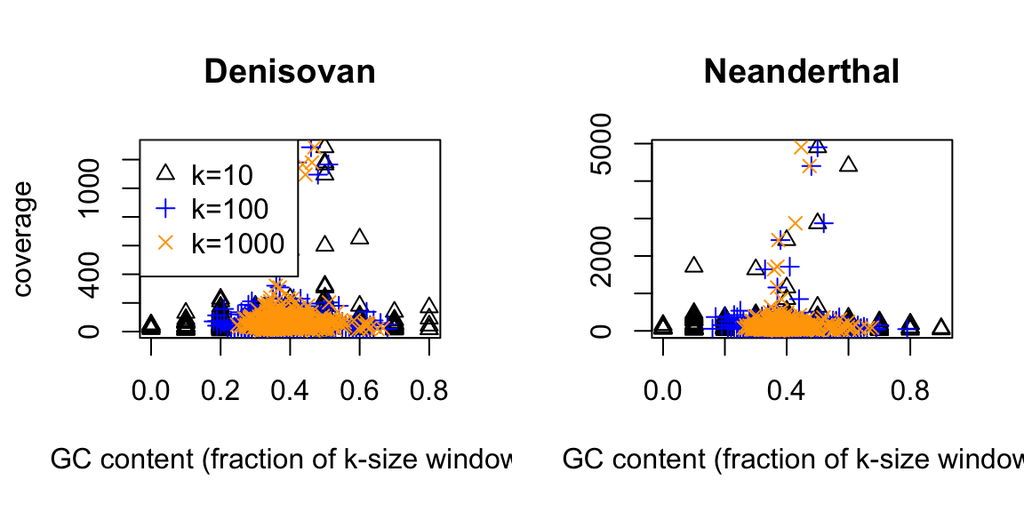

```r
# select non NA columns
denis_gc <- denis %>% select(., c('region','coverage','rollmean10','rollmean100','rollmean1000')) %>% drop_na()


# select non NA columns
neand_gc <- neand %>% select(., c('region','coverage','rollmean10','rollmean100','rollmean1000')) %>% drop_na()

# samples 500 points from each region
denis_small <- denis_gc  %>% sample_n(., size = 400)

# sample 500 points from each region
neand_small <- neand_gc  %>% sample_n(., size = 400)

# add columns to represent individual
denis_small$ind <- factor(rep(1, nrow(denis_small)))
neand_small$ind <- factor(rep(2, nrow(neand_small)))

# combine datasets
all_data <- rbind(denis_small,neand_small)

# plot coverage vs. the cg content for different k-values (denisovan)
layout(t(1:2))
with(all_data[all_data$ind==1,],{
  plot(rollmean10, coverage, col='black',
       pch=2, xlab='GC content (fraction of k-size window)', main='Denisovan')
  points(rollmean100, coverage, col='blue', pch=3)
  points(rollmean1000, coverage, col='orange', pch=4)
  legend('topleft',legend = c('k=10','k=100','k=1000'),pch=c(2,3,4), col = c('black', 'blue', 'orange'))
})

with(all_data[all_data$ind==2,],{
  plot(rollmean10, coverage, col='black',
       pch=2, xlab='GC content (fraction of k-size window)',
       main='Neanderthal',ylab='')
  points(rollmean100, coverage, col='blue', pch=3)
  points(rollmean1000, coverage, col='orange', pch=4)
})
```

The coverage seems to vary more over larger window sizes, and there is a larger variation in the neanderthal. I would guess that the window size with the greatest influence on coverage is k=100 because that is the bp size of each region, and regional gc content is known to effect regional coverage during sequencing.

The relationship between coverage and gc content over different window sizes can be modeled in stan, as follows:

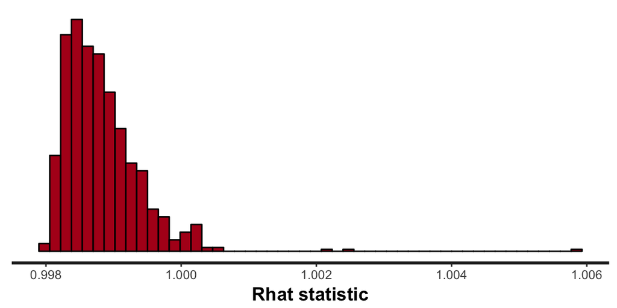

```r
gc_mod <- "data {
    int N; // number of sites
    vector[N] k10; // gc content within ±K bases
    vector[N] k100;
    vector[N] k1000;
    int ind[N]; // individual
    int z[N]; // coverage per site
    int nind; // per individaul
}
parameters {
    real<lower=0> alpha[N]; // poisson mean
    vector[nind] b;
    vector[nind] m1;
    vector[nind] m2;
    vector[nind] m3;
    real<lower=0> sigma;
}
model {
    vector[N] y;
    y = b[ind] + m1[ind] .* k10 + m2[ind] .* k100 + m3[ind] .* k1000;
    z ~ poisson(alpha);
    alpha ~ lognormal(y, sigma); // model noise into the mean
    b ~ normal(0, 20);
    m1 ~ normal(0, 20);
    m2 ~ normal(0, 20);
    m3 ~ normal(0, 20);
    sigma ~ normal(0, 20);
}"
gc_data <- list(N=nrow(all_data),
                k10=all_data$rollmean10,
                k100=all_data$rollmean100,
                k1000=all_data$rollmean1000,
                z=all_data$coverage,
                nind=length(levels(all_data$ind)),
                ind=as.numeric(all_data$ind))

# obtain posterior distibutions on the parameters
gc_fit <- stan(model_code = gc_mod, chains = 3, iter = 1000, data = gc_data)

# how well do the chains converging
stan_rhat(gc_fit, bins=50)
```

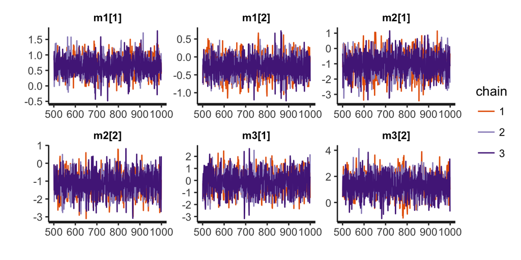

```r
# check for full mixing
stan_trace(gc_fit, pars=c('m1','m2','m3'))
```

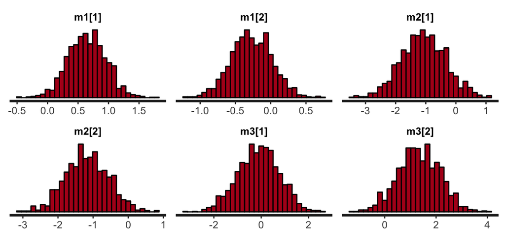

```r
# how do these distributions on our predictors look?
stan_hist(gc_fit, pars=c('m1','m2','m3'))
```

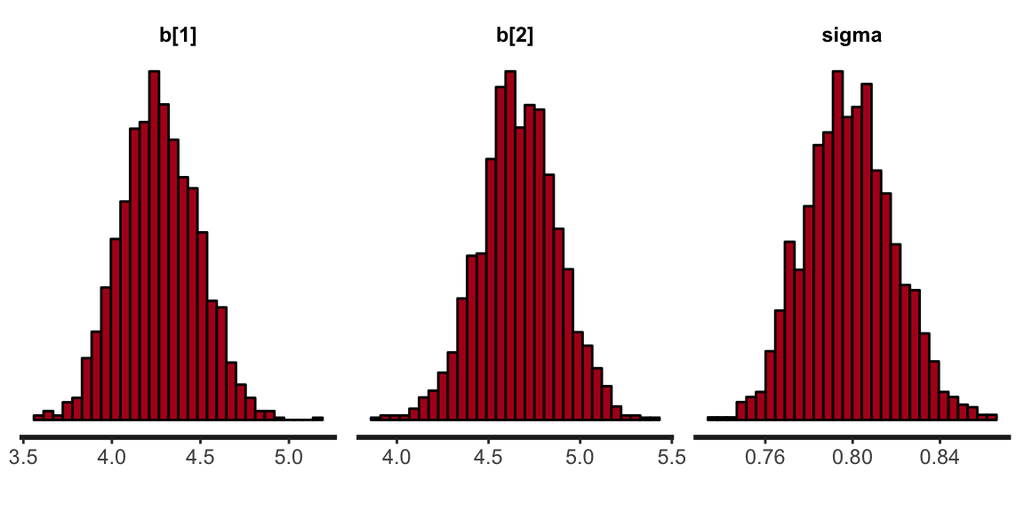

```r
stan_hist(gc_fit, pars = c('b','sigma'))
```

```r
# extract the posterior distributions from the fit
post_gc <- extract(gc_fit, pars=c('m1','m2','m3','b','sigma'))
```

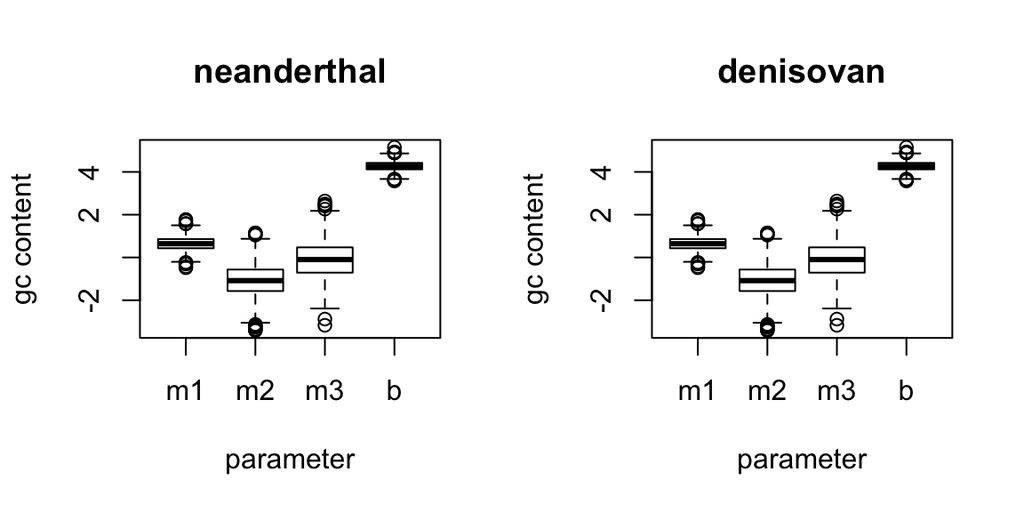

```r
# determine distributions across linear predictors for each individual
denis_post  <- NULL
for (name in names(post_gc)[1:4]){
    denis_post[[name]] <-  post_gc[[name]][,1]
}

neand_post <- NULL
for (name in names(post_gc)[1:4]){
    neand_post[[name]] <-  post_gc[[name]][,1]
}


# plot
layout(t(2:1))
boxplot(denis_post, main='denisovan', ylab='gc content', xlab='parameter')
boxplot(neand_post, main='neanderthal', ylab='gc content', xlab='parameter')
```

## Simulate the data

```r
# simulate data form the posterior distribution
nsamples <- nrow(all_data)

# grab estimates of the posterior mean from the parameters
params1 <- list(b=colMeans2(post_gc$b),
                m1=colMeans2(post_gc$m1),
                m2=colMeans2(post_gc$m2),
                m3=colMeans2(post_gc$m3),
                sigma=mean(post_gc$sigma))

# simulate data from 'guess' values
sim_data <- data.frame(k10 = rnorm(nsamples, 0.4, 0.03),
                       k100 = rnorm(nsamples, 0.4, 0.05),
                       k1000 = rnorm(nsamples,0.5, 0.1),
                       ind=sample(c(1,2), nsamples, replace=TRUE))

# simulate 100 datasets:
kk <- sample.int(nrow(post_gc$b), 100)
sims <- lapply(kk, function (k) {
                b <- post_gc$b[k,]
                m1 <- post_gc$m1[k,]
                m2 <- post_gc$m2[k]
                m3 <- post_gc$m3[k,]
                sigma <- post_gc$sigma[k]
                y <- with(list2env(sim_data), params1$b[ind] +
                        params1$m1[ind] * k10 +
                        params1$m2[ind] * k100 +
                        params1$m3[ind] * k1000)
                mu <- exp(rnorm(length(y),
                                mean=y, sd=sigma))
                rpois(length(mu), mu)
         })
sim1 <- do.call(cbind, sims)
```

## Plot the true data relative to the simulated data

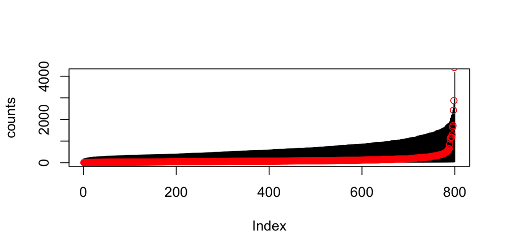

```r
library(matrixStats)

# plot the coverage agains the range of simulated values
plot(sort(all_data$coverage), ylab='counts', ylim=range(sim1),type='n')
segments(x0=seq_len(nrow(all_data)),
         y0=sort(rowMins(sim1)),
         y1=sort(rowMaxs(sim1)))
points(sort(all_data$coverage), pch=1, col='red')
```

Coverage values fall within the simulated data, this is a good sign! Though the simulated data looks a little over-predicted compared to the real coverage values. This can be measured by looking at the goodness of fit score we developed in class.

## Asess goodness of fit score

```r
gof <- function (z, x) {
    # z is a vector of observed counts
    # x is a (length(z) x N) matrix of simulated data
    sqrt(mean( ((z - rowMeans2(x)) / rowSds(x))^2 ))
}
# TEST THIS
z0 <- rnorm(5); x0 <- matrix(rnorm(50), nrow=5)
ans0 <- gof(z0, x0)
ans1 <- 0
for (i in 1:5) {
    ans1 <- ans1 + (z0[i] - mean(x0[i,]))^2 / var(x0[i,])
}
ans1 <- sqrt(ans1/length(z0))
stopifnot(abs(ans0 - ans1) < 5*.Machine$double.eps)


# obtain a goodness of fit score for the simulated data
gof_full <- gof(all_data$coverage, sim1)
```

#### How do the gof scores for the simulated data compare to that of the model gof score?

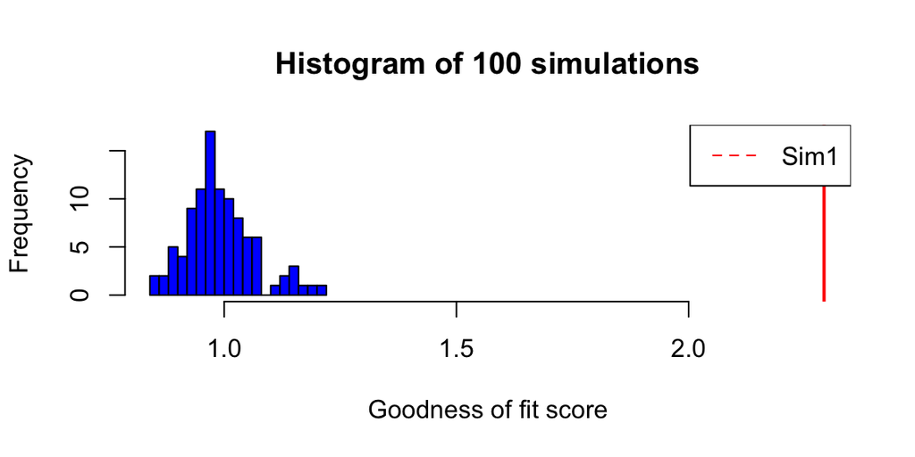

```r
more_sim <- do.call(cbind, sims)

gof_scores <- sapply(1:ncol(more_sim), function (k) {
                         z <- more_sim[,k]
                         x <- sim1
                         gof(z, x)
         } )
hist(gof_scores,
     xlim = c(min(gof_scores), gof_full),
     main = 'Histogram of 100 simulations',
     xlab = 'Goodness of fit score',
     breaks=20,
     col='blue')
abline(v=gof_full, col='red', lwd=2)
legend("topright", lty=2, col='red', legend="Sim1")
```

The GOF of the model falls outside that of the simulated datasets. This tells us that the simulated data doesn’t predict real data with great accuracy. This could tell us that there may be some other latent variable that is a better predictor of GC content than window size. Different parameterizations of the model could allow for a posterior distribution of parameter values that better predict the data.